# Model Builder for Item Factor Analysis with OpenMx

Joshua N. Pritikin

Department Psycholog University of Virginia

Karen M. Schmidt

Department Psychology, University of Virginia

2016-04-03

Abstract

We introduce a shiny web application to facilitate the construction of Item Factor Analysis (a.k.a. Item Response Theory) models using the *OpenMx* package. The web application assists with importing data, outcome recoding, and model specification. However, the app does not conduct any analysis but, rather, generates an analysis script. Generated Rmarkdown output serves dual purposes: to analyze a data set and demonstrate good programming practices. The app can be used as a teaching tool or as a starting point for custom analysis scripts.

# An overview of *OpenMx*

[*OpenMx*](https://CRAN.R-project.org/package=OpenMx), a modular package originally designed for structural equation modeling (Neale et al. in press), recently gained the ability to handle Item Factor Analysis (a.k.a. Item Response Theory, Modern Test Theory) models (Pritikin, Hunter, and Boker 2015). Although a goal of *OpenMx* is to cater to the statistical power user and facilitate analyses that are difficult to conduct in other software, the development team is always on the lookout for ways to ease the learning curve for novice users as well. Here we introduce a new [*shiny*](https://CRAN.R-project.org/package=shiny) (RStudio and Inc. 2014) web application to generate *OpenMx* code in [*Rmarkdown*](https://CRAN.R-project.org/package=Rmarkdown) format (Allaire et al. 2014). We believe this code generator substantially lowers the barrier to entry for novice users of Item Factor Analysis (IFA) and encourages a culture of literate programming (Knuth 1984) and reproducible science (Peng 2011; Nosek et al. 2015). The generated code can be customized at many levels. This flexibility enables the production of custom analyses and reports as users grow more sophisticated in their modeling expectations.

# The statistical model

Item analysis is concerned with items that are scored correct/incorrect or on an ordinal scale. Many psychological surveys use an ordinal scale. For example, participants may be asked to respond to an item like, “I feel I am in charge of the situation in which I live.” on a 5-point Likert scale from *agree* to *disagree*. Whether dichotomous or ordinal, the conditional likelihood of response $x_{ij}$ to item $j$ from person $i$ with item parameters $\xi_j$ and latent ability (a.k.a. latent trait) $\theta_i$ is
$$\begin{aligned}
\label{eq:response}
L(x_i|\xi,\theta_i) = \prod_j \mathrm{Pr}(\mathrm{pick}=x_{ij} |
\xi_j,\theta_i).
\end{aligned} (\#eq:response)$$
One implication of Equation @ref(eq:response) is that items are assumed to be conditionally independent given the latent ability $\theta_i$. That is, the outcome of one item does not have any influence on another item after controlling for $\xi$ and $\theta_i$. The unconditional likelihood is obtained by integrating over the latent distribution $\theta_i$,
$$\begin{aligned}
\label{eq:integral}
L(x_i|\xi) = \int L(x_i|\xi, \theta_i) L(\theta_i) \mathrm{d}\theta_i.
\end{aligned} (\#eq:integral)$$
With an assumption that examinees are independently and identically distributed, we can sum the individual log likelihoods,
$$\begin{aligned}
\label{eq:ifa-model}
\mathcal{L}=\sum_i \log L(x_i | \xi).
\end{aligned} (\#eq:ifa-model)$$
Optimization consists of finding the $\xi$ that maximizes this function. *OpenMx* presently offers only one choice for optimization, an Expectation-Maximization algorithm using equal interval quadrature to evaluate the integral in Equation @ref(eq:integral) (Bock and Aitkin 1981). In the future, we plan to add complementary algorithms such as Metropolis-Hastings Robbins-Monro, that is more efficient at optimizing certain problems (Cai 2010b).

Several models are readily available to plug in as the response probability function $\mathrm{Pr}(\mathrm{pick}=x_{ij} | \xi_j,\theta_i)$ in Equation @ref(eq:response). All of these response probability functions are built from the logistic function,
$$\text{logistic}(l) \equiv
\text{logit}^{-1}(l) \equiv \frac{1}{1+\exp(-l)}.$$
Details of the parameterizations are given here. A discussion of these item models more appealing to intuition is given in the next section.

## Dichotomous model

The dichotomous response probability function can model items when there are exactly two possible outcomes. It is defined as,
$$\begin{aligned}
\label{eq:dichotomous}
\mathrm{Pr}(\text{pick}=0| a,b,g,u,\tau) &= 1-
\mathrm{Pr}(\text{pick}=1| a,b,g,u,\tau) \\
\mathrm{Pr}(\text{pick}=1| a,b,g,u,\tau) &=
\text{logit}^{-1}(g)+(\text{logit}^{-1}(u)-\text{logit}^{-1}(g))\frac{1}{1+\exp(-(
a\tau + b))}
\end{aligned} (\#eq:dichotomous)$$

where $a$ is the slope, $b$ is the intercept, $g$ is the pseudo-guessing lower asymptote expressed in logit units, $u$ is the upper asymptote expressed in logit units, and $\tau$ is the latent ability of the examinee (Birnbaum 1968; Loken and Rulison 2010). A *#PL* naming shorthand has been developed to refer to versions of the dichotomous model with different numbers of free parameters. Model $n$PL refers to the model obtained by freeing the first $n$ of parameters $b$, $a$, $g$, and $u$.

## Graded response model

The graded response model is a response probability function for 2 or more outcomes (Samejima 1969; Cai 2010b). For outcomes k in 0 to K, slope vector $a$, intercept vector $b$, and latent ability vector $\tau$, it is defined as,
$$\begin{aligned}
\mathrm{Pr}(\text{pick}=K| a, b,\tau) &= \frac{1}{1+\exp(-( a\tau +
b_K))}\\
\mathrm{Pr}(\text{pick}=k| a, b,\tau) &= \frac{1}{1+\exp(-( a\tau +
b_k))} - \frac{1}{1+\exp(-( a\tau + b_{k+1}))} \\
\mathrm{Pr}(\text{pick}=0| a, b,\tau) &= 1-
\mathrm{Pr}(\text{pick}=1| a,b_1,\tau).
\end{aligned}$$

## Nominal model

The nominal model is a response probability function for items with 3 or more outcomes (e.g., D. Thissen, Cai, and Bock 2010). It can be defined as,
$$\begin{aligned}
\label{eq:nominalT}
a &= T_a \alpha \\
c &= T_c \gamma \\
\mathrm{Pr}(\text{pick}=k| s,a_k,c_k,\tau) &= C\ \frac{1}{1+\exp(-(
s \tau a_k + c_k))}
\end{aligned} (\#eq:nominalT)$$
where $a_k$ and $c_k$ are the result of multiplying two vectors of free parameters $\alpha$ and $\gamma$ by fixed matrices $T_a$ and $T_c$, respectively; $a_0$ and $c_0$ are fixed to 0 for identification; $s$ is the per-item slope; and $C$ is a normalizing constant to ensure that $\sum_k \mathrm{Pr}(\text{pick}=k) = 1$.

# Item models

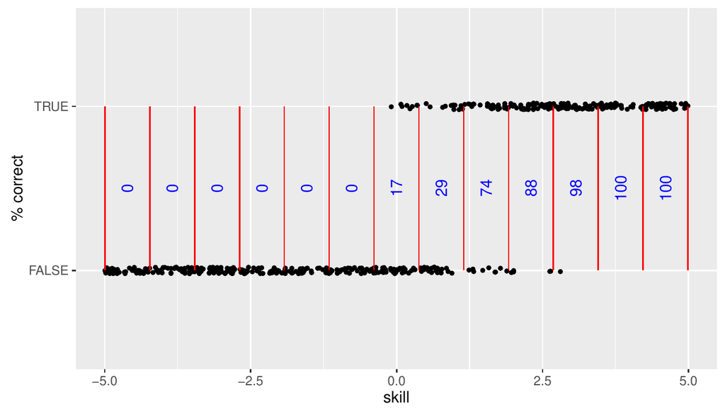

Figure 1: Dichotomous data converted into continuous data conditional on examinee skill.

Modern test theory employs item models, $\mathrm{Pr}(\mathrm{pick}=x_{ij} | \xi_j,\theta_i)$ (from Equation @ref(eq:response)). To better appreciate how modern test theory works, it is helpful to develop an intuitive understanding of item models. The essential idea is the conversion of ordinal (or dichotomous) data into continuous data conditional on examinee skill. In Figure 1, the black dots represent the dichotomous data. Here we assume that examinee skill is known so that we can plot the black dots at the appropriate place on the $x$ axis. The next step is to partition the $x$ axis into equal interval bins. The proportion of examinees who responded correctly is displayed in blue in the middle of each bin. These blue numbers are our new continuous data, conditional on examinee skill. While we assumed that examinee skill was known, this assumption is actually unnecessary. The optimization algorithm can make a rough estimate of examinee skill, proceed to improve the model, and repeat this process until change is less than some epsilon.

To further inform your intuition about item models, it can be helpful to place yourself in the position of the optimization algorithm. Enter the following commands to launch the model explorer tool and browse to the output web server address. It is possible to do this without *RStudio*, but *RStudio* makes everything easier so we recommend using *RStudio*. Note that the port number (`3726` printed below) may be different on your computer.

```r
> library(ifaTools)
> itemModelExplorer()

Listening on http://127.0.0.1:3726
```

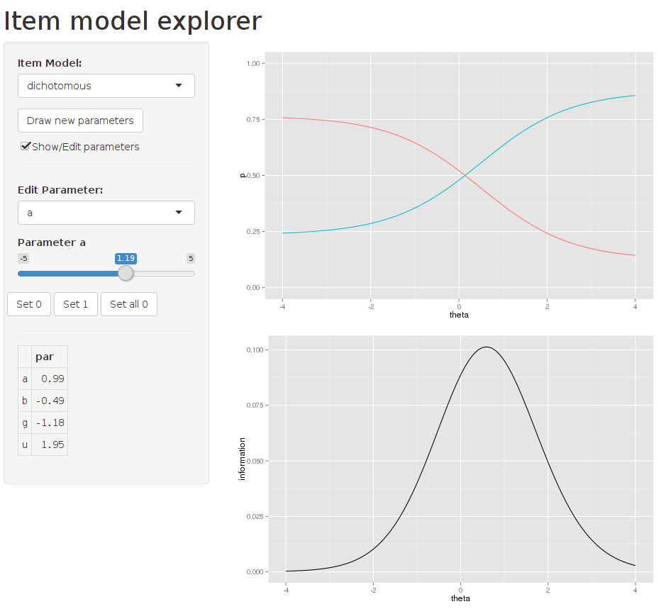

Figure 2: Item model explorer with the dichotomous model selected. The upper plot exhibits the model predicted chance of outcomes conditional on the latent trait (theta). The lower plot exhibits the theoretical item information conditional on the latent trait.

Your browser should show a screen similar to Figure 2. Try experimenting with all the controls. Early in the development of item models, model parameters closely corresponded to the psychological concepts of *difficulty* and *discrimination* (Birnbaum 1968). For example, difficult items are only answered correctly by the brightest examinees while most examinees may correctly answer easy items. *Discrimination* quantifies how much we learn from a given response. Well-designed items discriminate examinee skill. The causes of poor item discrimination are many. An item may be hurt by awkward wording, by asking examinees something that is somewhat off-topic, or by asking the same question in slightly different ways.

Some item model parameters still retain a close connection to difficulty and discrimination. For example, the dichotomous model’s $a$ parameter corresponds with discrimination and the negative $b$ parameter divided by $a$ corresponds with difficulty (Equation @ref(eq:dichotomous)). However, as item models have grown more flexible, the parameter values and intuitive interpretation have become more distant. To understand item models in general, it is helpful to plot category curves and information by the latent trait (Figure 2). Some examples of latent traits which can be measured in this framework are mathematical skill, vocabulary, or sleep quality.

The way to interpret these plots is to start by picking a value for the latent trait. Suppose we know that examinee Alice has a latent ability of 2 logit units. If we trace across the plot where the $x$ axis is 2 then we find that Alice has a 75% chance of getting the item correct (blue curve) and a 25% chance of getting it incorrect (red curve). In addition, we find that this item will give us 0.05 units of information about Alice (black curve). The difficulty of the item is where the correct and incorrect curves cross at about 0.2 logits. The discrimination of the item is given by the information plot. This item provides more information about examinees with latent skill between $-1$ and $2$ than elsewhere on the skill continuum.

Much can be gleaned about item models by inspection of these plots. However, it is worth conveying a few additional details specific to particular item models. The dichotomous model’s $g$ and $u$ asymptote parameters are in logit units. To transform these values back into probabilities use R’s `plogis` function. The $g$ parameter may represent the chance of an examinee guessing the item correctly. This parameter is also often called the pseudo-guessing parameter due to the probability of a low ability examinee getting an item correct at a non-zero asymptote. The $u$ parameter, or upper asymptote parameter, may represent the chance of an examinee committing a careless mistake, reflecting high ability examinee behavior. In this case, the upper asymptote never reaches one (Loken and Rulison 2010).

By default, the nominal model uses *trend* for the `T.a` and `T.c` matrices (Equation @ref(eq:nominalT)). This parameterization is also known as the Fourier basis. The effect is that the `alf` and `gam` parameters control the lowest frequency variation to the highest frequency variation. To develop an intuition for how this works, set all parameters to zero then set `a`, `alf1` and `gam2` to 1. Experiment with the `gam` parameters before you experiment with the `alf` parameters. Refer to D. Thissen, Cai, and Bock (2010) for discussion of the possibilities of this item model. Custom `T.a` and `T.c` matrices are not available in the model explorer app, but can be specified in R code.

The “`Show/Edit parameters`” checkbox has a special didactic purpose. Open two copies of the item model explorer. On one copy, un-check the “`Show/Edit parameters`” checkbox to hide the parameters and click the “`Draw new parameters`” button. On the second copy of the item model explorer, adjust the item model parameters to try to match the plot produced on the first item model explorer. You can check your answers by checking the “`Show/Edit parameters`” checkbox. When you play this game, you are doing part of what the optimization algorithm does when it fits models to data. Note that there is no need to practice this skill. The computer will do it for you.

# The model builder

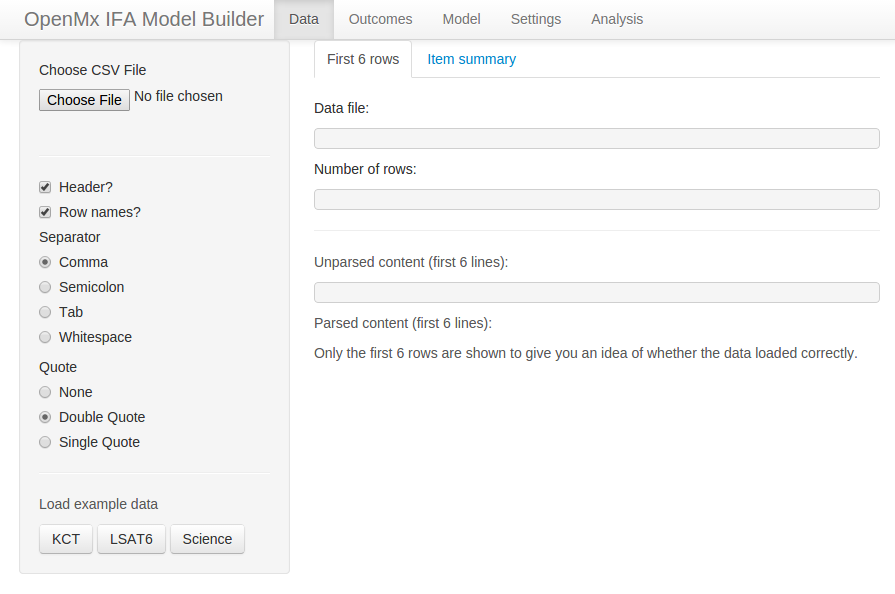

Figure 3: Initial screen shown after start up.

Enter the following commands to launch the model builder tool and browse to the output web server address. As before, it is possible to do this without *RStudio*, but *RStudio* makes everything easier so we recommend using *RStudio*. Note that the port number (`3726` printed below) may be different on your computer.

```r
> library(ifaTools)
> modelBuilder()

Listening on http://127.0.0.1:3726
```

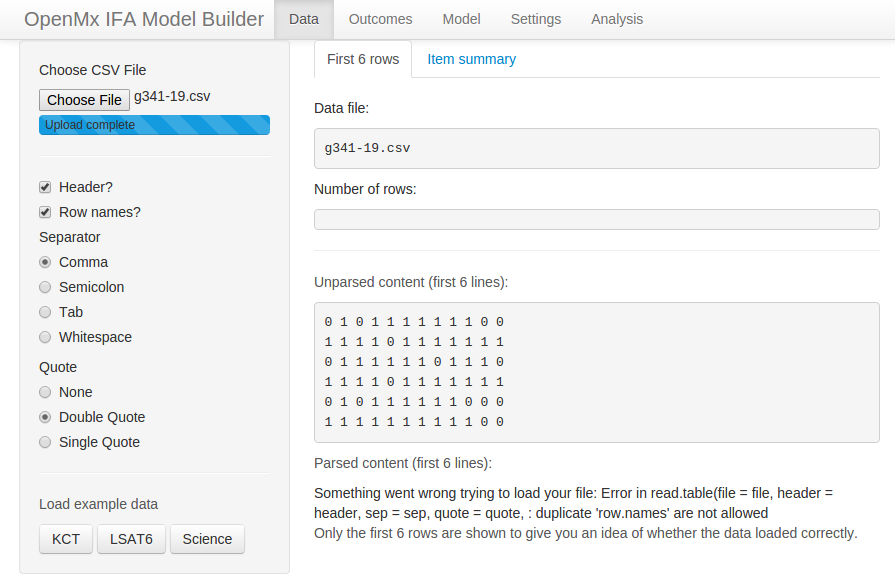

Figure 4: After loading the `g341-19.csv` data.

Your browser should show a screen similar to Figure 3. Take care not to hit the `Reload` button because that will reset the app. Learn how to save your work (detailed below) before you experiment with the `Reload` button. Across the top are tabs that organize the major functions of the model builder app. On the left side is a control panel for the currently selected tab `Data`. Example data sets are available at the bottom of the control panel. You are welcome to experiment with these, but we will focus on the process of loading an external data set. If you prefer to follow along with a video then browse to http://youtu.be/xHeb5_CWnCk for dichotomous data and http://youtu.be/iwtpleltteQ for polytomous data.

# Dichotomous data

Click on the “`Choose File`” button[^1] and select `g341-19.csv`, a dichotomous data set that is available in the [*ifaTools*](https://CRAN.R-project.org/package=ifaTools) package (Pritikin 2015a). The first 6 lines will appear in the “`Unparsed content`” section (see Figure 4).[^2] This makes it easy to see how the file is formatted. The “`Parsed content`” section reports an error. By reading the error carefully, you will find mention that “duplicate ‘row.names’ are not allowed.” Since “`Row names?`” is enabled in the control panel, the model builder app expects the first column of data to be dedicated to row names. A row name is typically the examinee’s name or numeric identifier. A glance at the unparsed content reveals that no row names have been given in this data set.

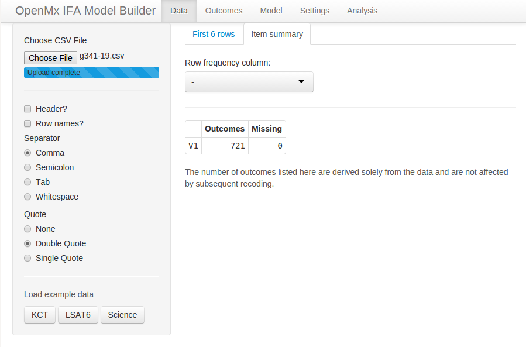

Figure 5: A summary of the `g341-19.csv` data set when parsed incorrectly as a single column.

Click the “`Row names?`” checkbox in the control panel to disable row names. Immediately (without reloading the data), the error message in the “`Parsed content`” section will be replaced by some of the data organized into a single column. The column name will read `X010111111100`. A column name like that should raise suspicion. Since the “`Header?`” checkbox is enabled in the control panel, the model builder app expects the first line of the data to contain column names. Therefore, the first line of data is misinterpreted.

Click the “`Header?`” checkbox in the control panel to disable column names. The column in the “`Parsed content`” section will now be labeled `V1`. Click on the “`Item summary`” control as an alternate way to verify that the data is loaded and parsed accurately. The main content area includes two elements, a selection for the “`Row frequency column`” and a table of items by `Outcomes` and `Missing` (see Figure 5). The “`Row frequency column`” selection is used when you have already reduced your data to unique rows and row counts. The example data set `LSAT6` is in this format. For our current data set, leave “`Row frequency column`” set to $-$.

The information conveyed in the item table should rouse suspicion. There is only 1 row (or 1 item) with 721 outcomes. What happened is that the parsing is still not working and all the items are treated as a single column. For example, the first row “0 1 0 1 1 1 1 1 1 1 0 0” is not treated as 12 separate numbers but as a single uninterpreted unit. To fix the parsing, we need to select `Whitespace` as the `Separator` in the control panel. With this last error corrected, the table is updated with 12 items labeled V1, V2, …, V12 and all with 2 outcomes. With the data correctly loaded, click on the “`Outcomes`”tab on the top bar.

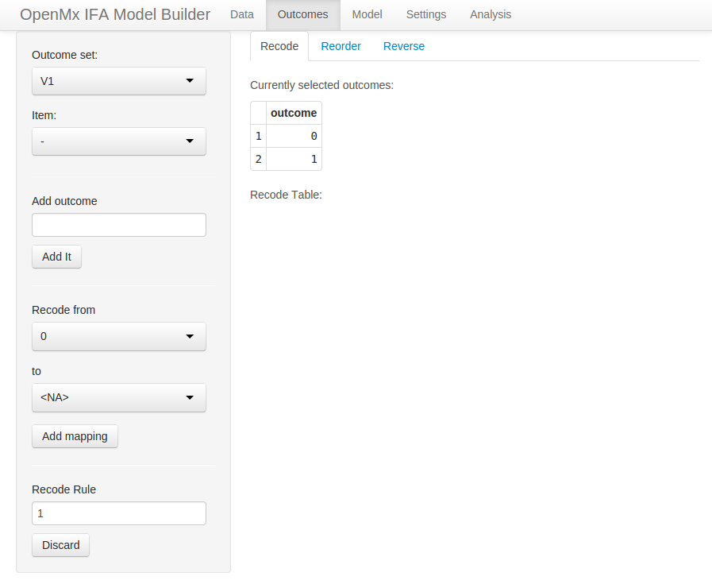

Figure 6: The Outcomes tab without any recoding rules.

The control panel on the “`Outcomes`” tab packs a lot of functionality (Figure 6). The first two selectors are mutually exclusive and permit working with all items having the same outcomes or with specific items, respectively. The outcome set “V1” is currently selected as seen in the control panel on the left side. In these data, all items have the same possible outcomes (0 or 1). Therefore, there is only one outcome set. The name “V1” does not just refer to the item “V1” but to all items, because all items have the same outcomes.

For clarity, it is often helpful to rename outcomes. The “`Recode from`” selector should have “0” selected. Change the `to` selector to `<Rename>`, enter “incorrect” for the “`New name`” value, and click the “`Add mapping`” button. This will create a recoding rule that will show up in the “`Recode Table`” output (Figure 7). Similarly, rename the “1” outcome to “correct” and again click the “`Add mapping`” button. At this point, you should have 2 rules in the “`Recode Table`” output.

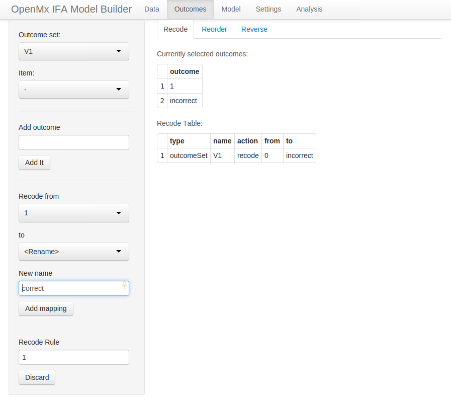

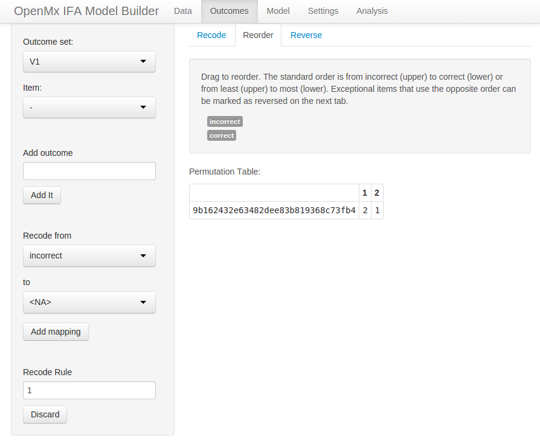

Figure 7: (left) The outcome ”0” is renamed to ”incorrect” and we are poised to rename ”1” to ”correct.” In a moment, we will click the ”`Add mapping`” button. (right) The outcome reorder tool with 1 reordering rule.

Click on the “`Reorder`” tab. Here you will find the outcomes sorted in lexical order. Drag one of the outcomes to reverse the order (as in Figure 7). Similar to the operation of renaming outcomes, this reordering step is not strictly necessary but is often helpful to keep things straight in our minds. With dichotomous outcomes, there are not that many ways that things can go wrong. However, it is good practice to use self-explanatory labels and standardized ordering. This is especially true when there are more than 2 outcomes to worry about.

We will not use the “`Reverse`” tab and other control panel elements in the present example. In survey design, it is common for outcomes to have a canonical order with some items reverse scored. The “`Reverse`” tab is used to reverse the outcome order of some subset of items without dragging the outcomes around with the “`Reorder`” tool. This can save a lot of dragging when there are more than 2 outcomes. The “`Add outcome`” tool permits the addition of outcomes that are not represented in the data. This might happen when a measure is in development and we are fitting a preliminary model just to get a vague idea of how the item is working. To fit an item that lacks data on some outcomes, it is usually necessary to use the nominal response model with a less than full rank parameterization (similar to D. Thissen, Steinberg, and Mooney 1989). In addition to renaming, the recode mappings tool can merge or collapse outcomes.

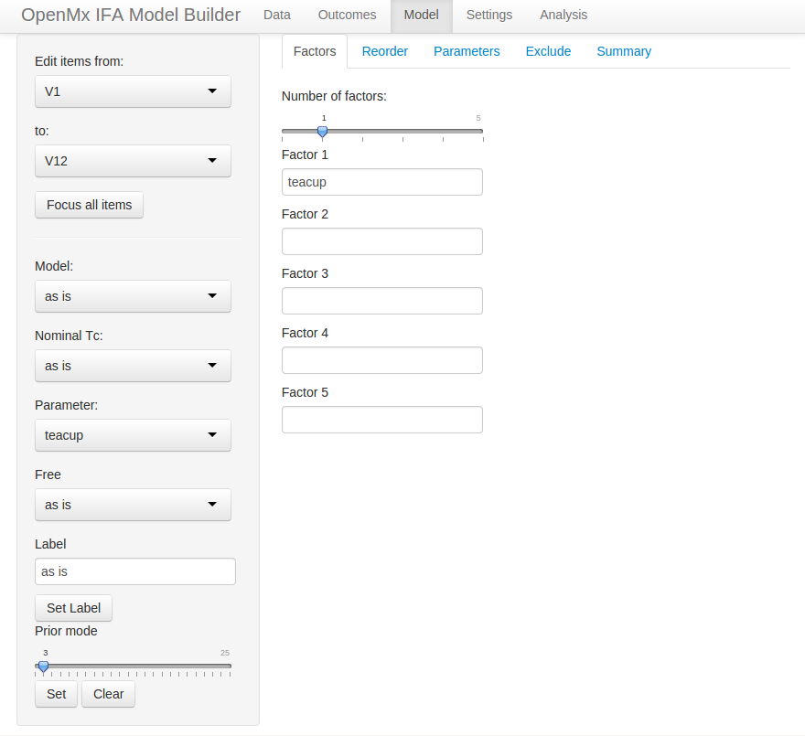

Figure 8: Configuration of latent factors.

For example, we might have an outcome set consisting of “Agree,” “Agree somewhat,” “Not sure,” “Disagree somewhat,” and “Disagree.” It is straightforward to merge “Agree somewhat” to “Agree” and “Disagree somewhat” to “Disagree,” resulting in only 3 outcomes. Of course, it is not always obvious which outcomes to merge. The recode tool can also recode an outcome to `<NA>`, which causes that outcome to be interpreted as missing. Finally, the “`Discard`” button at the bottom of the control panel allows us to discard any rule that we created. So feel free to experiment.

Click on the “`Model`” tab on the top bar. The first decision we need to make is how many latent factors to include in our model (Figure 8). If we are not sure, a good starting point is 1. By default, the first latent factor is called `teacup`. In case there was any doubt, “teacup” is not a very good name for a latent trait. We deliberately picked ridiculous factors names to encourage users to pick names that make sense in the context of the data under analysis. For example, a good factor name for a math test might be `math`. If you cannot think of a good factor name, you could use “latent trait,” but this name only works well for a single factor model. You really should make an effort to think of descriptive names before you start using trait1, trait2, etc. If you are not sure how many factors to use then use 1 for now. We will revisit this question later.

The “`Reorder`” tab allows you to change the order of your items. This can be helpful because of the way that item model and parameter editing works. To get familiar with how item editing works, click on the “`Parameters`” tab. The main content area of the “`Parameters`” tab contains a lot of information. The first thing to notice is that all of the tables have the same column labels. Each item is assigned to a column. Using the control panel, we will focus on only a subset of items. Change the first selector “`Edit items from:`” from `V1` to `V7`. This will hide the first 6 items, making the tables in the main content area look more manageable (Figure 9). The first two selectors facilitate item range selection. To reveal all items again, use the “`Focus all items`” button. Item selection is important to understand because the remainder of the controls in the control panel operate on only the selected (visible) items.

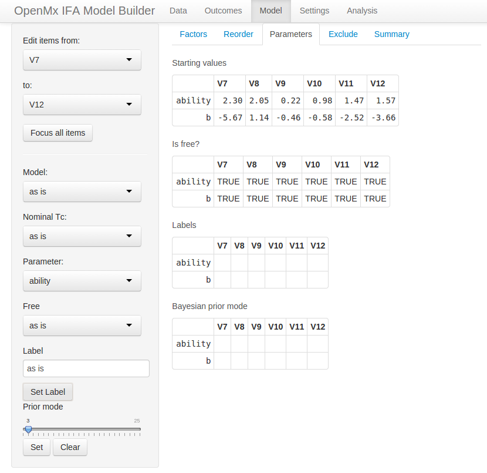

Figure 9: Editing the models and parameters of a subset of items.

With only items `V1` to `V6` visible, select `drm` from the “`Model`” selector. The value `drm` is an abbreviation for the 4PL dichotomous response model (Loken and Rulison 2010), which has four parameters when there is one factor. The `g` and `u` rows should appear in all of the tables in the main content area. Parameter `g` is the pseudo-guessing lower bound and `u` is the upper bound. The upper bound has been used to better model high ability examinees in a Computerized Adaptive Testing context (Magis 2013). Even high ability examinees may occasionally miss an easy item. Here we will fix the upper bound to 1 (meaning that an examinee with sufficiently high ability will never answer incorrectly). Since the bound parameters are expressed on a logit scale, we will use $\text{logit}(1)$. Select `u` from the “`Parameter`” selector and `Inf` from the “`Free`” selector (since $\text{logit}(1)=\inf$). The row of “`Starting values`” for `u` should change to `Inf` and the corresponding “`Is free`” row should change from `TRUE` to `FALSE`. With this constraint, the 4PL dichotomous response model is equivalent to the 3PL model (Birnbaum 1968).

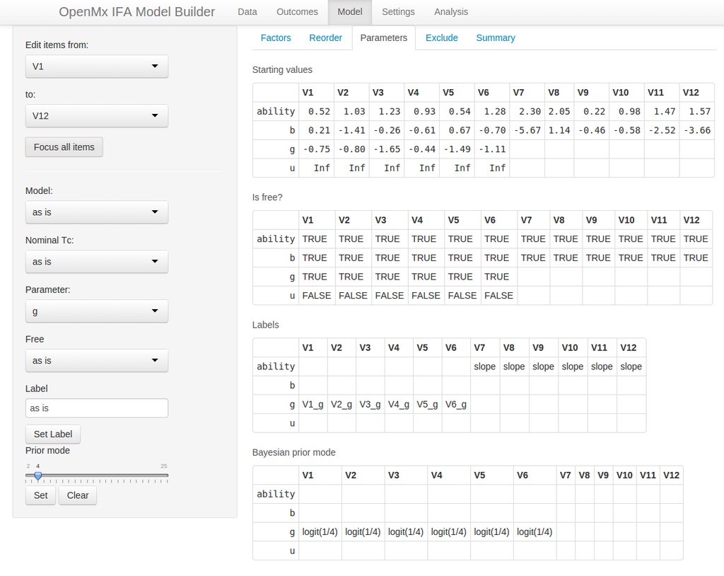

Figure 10: Item tables after setting up our model.

The pseudo-guessing lower bound `g` represents the chance that an examinee will get the item correct by guessing. Typically, the expected guessed-correct probability for a 3-alternative item is $\frac{1}{3}$ and $\frac{1}{n}$ for an $n$-alternative item. Estimating the lower bound from data without telling the model a priori how many alternatives were presented typically requires much more data than is required to estimate other kinds of parameters. This is especially true for easy items because few participants will need to guess. It could be argued that easy items should have the lower bound set to a probability of zero. However, in an item set with some lower bounds fixed to zero and some free, the items with the lower bounds fixed to zero will provide more information than the items that take the chance of guessing into account. Therefore, we suggest fixing the lower bound to $\frac{1}{n}$ for an $n$-alternative item when estimation of the lower bound is not of interest.

As a compromise between fixing and freeing, a Bayesian prior can be used with the mode of the prior set to the expected probability. While some researchers are uneasy about the use of priors (Gelman 2008), the practice is not new (e.g, Baker and Kim 2004, chap. 7). The prior ensures that a parameter will converge even when there is not enough data to estimate it, but at the same time, the model retains some flexibility to adapt to unexpected data. To set a prior, drag the “`Prior mode`” slider and click the “`Set`” button. Let us imagine that these items had 4 alternatives. Select `g` from the `Parameter` selector, move the “`Prior mode`” slider to 4, and click the nearby `Set` button. Two tables will change. Each cell of the `g` row of the `Labels` table will be assigned a unique label. This is necessary because Bayesian priors are associated with labels, not with particular parameters. In addition, the “`Bayesian prior mode`” table will show $\text{logit}(1/4)$ in the `g` row. The logit usage reflects that the parameter is estimated on the logit scale, but it is much easier for humans to understand a probability expressed as a fraction rather than raw logit units.

We will not use the “`Nominal Tc`” selector for these data. “`Nominal Tc`” only applies to items with more than 2 possible outcomes when using the nominal response model (D. Thissen, Cai, and Bock 2010). Before proceeding, go ahead and click the “`Focus all items`” button. Your screen should look like Figure 10, except for different starting values. Click on the “`Exclude`” tab. This is an easy way to exclude some of the items from analysis. Finally, click on the “`Summary`” tab. Here you will find a summary of your model settings. Note that the number of outcomes may differ from the number of outcomes reported in the summary table found on under the “`Data`” top bar page due to recoding.

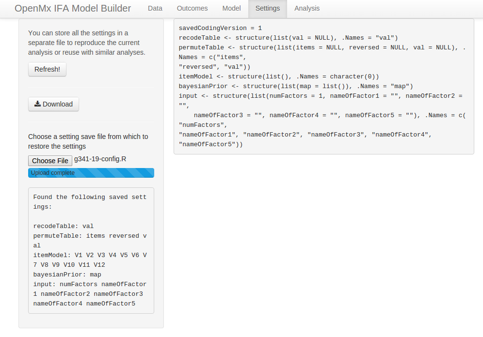

Figure 11: Restoring the settings.

We are done setting up our model. Before proceeding, it would be wise to save our model configuration so we can come back at a later time and make small adjustments without going through the whole exhaustive process again. Click `Settings` on the top bar. In the main content area, you will find a preview of what the settings file will look like. Click the “`Download`” button and move the file to a suitable location on your computer.

To verify that you can reliably restore the saved settings, open a new browser tab to the same address by pasting the URL address from the current tab (without closing the current one). You should get a screen like Figure 3. Again go through the procedure of loading the data (Figures 4 and 5). Once your data is loaded, click `Settings` on the top bar and load the file that you recently saved. If all goes well, you should see a screen similar to Figure 11. Go ahead and look back through the editors under the `Outcomes` and `Model` sections of the top bar. You should find all your hard work faithfully preserved. Now you can close either of the 2 browser tabs that you have open. They both have the same status.

With our model set up and saved, click `Analysis` on the top bar. This screen looks and functions similarly to the `Settings` screen. However, the control panel offers a few options specific to code generation. The “`Functional form for dichotomous bound prior density`” selector chooses the distributional form of the Bayesian prior. `Logit-normal` is the more recent scheme (Cai, Yang, and Hansen 2011). The “`Information matrix method`” control is set to `Oakes` by default. In a simulation study included with *OpenMx*, the Oakes method (Oakes 1999) exhibited accuracy comparable to central difference with Richardson extrapolation and time linear in the number of parameters. Click the “`Download`” button and save the `Rmarkdown` code. The `Rmarkdown` file and your data need to be in the same directory. Either move the `Rmarkdown` file to your data directory, or alternately, you can specify a full path in the read.csv statement (lines 16–17). Open the file in *RStudio* and click the “`Knit HTML`” button.

````r
---
title: "g341-19"
date: "14-Nov-2014"
output: html_document
---

```{r}
options(width = 120, scipen = 2, digits = 2)  ## \label{e1:options}
suppressPackageStartupMessages(library(OpenMx))    ## \label{e1:pkg1}
suppressPackageStartupMessages(library(rpf))
suppressPackageStartupMessages(library(ifaTools))
library(xtable)
options(xtable.type = 'html')    ## \label{e1:pkg2}

# Adjust the path in the next statement to load your data
data <- read.csv(file = 'g341-19.csv', header = FALSE, sep = ' ', ## \label{e1:load1}
  stringsAsFactors = FALSE, check.names = FALSE) ## \label{e1:load2}
colnames(data) <- mxMakeNames(colnames(data), unique = TRUE) ## \label{e1:colnames}

factors <- "ability"  ## \label{e1:factor1}
numFactors <- length(factors)
spec <- list()
spec[1:6] <- rpf.drm(factors = numFactors)
spec[7:12] <- rpf.grm(factors = numFactors, outcomes = 2)  ## \label{e1:factor2}
names(spec) <- c("V1", "V2", "V3", "V4", "V5", "V6", "V7", "V8", "V9", "V10",
  "V11", "V12")

missingColumns <- which(is.na(match(names(spec), colnames(data)))) ## \label{e1:colmatch}
if (length(missingColumns)) {
  stop(paste('Columns missing in the data:',
    omxQuotes(names(spec)[missingColumns])))
}

data[names(spec)] <- mxFactor(data[names(spec)], levels = 0:1, ## \label{e1:mxfactor}
  labels = c("incorrect", "correct"))

set.seed(1)   # uncomment to get the same starting values every time
startingValues <- mxSimplify2Array(lapply(spec, rpf.rparam))
rownames(startingValues) <- paste0('p', 1:nrow(startingValues))
rownames(startingValues)[1:numFactors] <- factors

imat <- mxMatrix(name = 'item', values = startingValues,
  free = !is.na(startingValues)) ## \label{e1:item}
imat$free['p4',1:6] <- FALSE
imat$values['p4',1:6] <- Inf
imat$labels['ability',7:12] <- 'slope'
imat$labels['p3',1:1] <- 'V1_g'
imat$labels['p3',2:2] <- 'V2_g'
imat$labels['p3',3:3] <- 'V3_g'
imat$labels['p3',4:4] <- 'V4_g'
imat$labels['p3',5:5] <- 'V5_g'
imat$labels['p3',6:6] <- 'V6_g'
hasLabel <- !is.na(imat$labels)
for (lab1 in unique(imat$labels[hasLabel])) {
  imat$values[hasLabel & imat$labels == lab1] <-
    sample(imat$values[hasLabel & imat$labels == lab1], 1)
}
data <- compressDataFrame(data)
itemModel <- mxModel(model = 'itemModel', imat,
  mxData(observed = data, type = 'raw',
    numObs = sum(data[['freq']]), sort = FALSE),
  mxExpectationBA81(ItemSpec = spec, weightColumn = 'freq'),
  mxFitFunctionML())

priorLabels <- c("V1_g", "V2_g", "V3_g", "V4_g", "V5_g", "V6_g")
priorParam <- mxMatrix(name = 'priorParam', nrow = 1,
  ncol = length(priorLabels), free = TRUE, labels = priorLabels)
priorParam$values <- imat$values[ match(priorParam$labels, imat$labels) ]
priorMode <- c(priorParam$values)
priorMode[1:6] <- logit(1/4)
priorModel <- univariatePrior('logit-norm', priorLabels, priorMode)
container <- mxModel(model = 'container', itemModel, priorModel,  ## \label{e1:container}
  mxFitFunctionMultigroup(groups = c('itemModel.fitfunction',
                                   'univariatePrior.fitfunction')))

emStep <- mxComputeEM('itemModel.expectation', 'scores',
  mxComputeNewtonRaphson(), verbose = 2L,  ## \label{e1:verbose}
  information = 'oakes1999', infoArgs = list(fitfunction = 'fitfunction'))
computePlan <- mxComputeSequence(list(EM = emStep,
         HQ = mxComputeHessianQuality(),
         SE = mxComputeStandardError()))

m1Fit <- mxRun(container) ## \label{e1:run}

m1Grp <- as.IFAgroup(m1Fit$itemModel, minItemsPerScore = 1L)  ## \label{e1:ifagroup}
```
````

The details of the generated report are likely to evolve. There may be some differences between the generated code in this article and the most recent version, but there should be a correspondence between the basic elements. The first chunk of code builds the model and optimizes it. We adjust the output of long lines and numbers (line 8) and load packages (lines 9–13). The data set is loaded (Figure 5) in lines 16–17. Latent factors are configured (Figure 8) in lines 20–24. We strongly encourage the use of informative column (item) names, but line 18 will take care of assigning syntactically valid column names if informative names are not available. The script is crafted such that it can work on other data sets as long as the required columns are found (line 28). `mxFactor` does the recoding and reordering (Figures 6–7). `mxFactor` offers a number of important safety and convenience features beyond what is available from `factor` or `ordered` (line 34). The item `mxMatrix` (line 43) contains most of the information in the item tables (Figure 10). Everything goes into the `container` model (line 72). The model is optimized (line 83). Since we did not disable "`Show model fitting progress`" (reflected by `verbose = 2L` at line 77), we obtain some diagnostics upon knitting the `Rmarkdown` to HTML.

```r
[0] ComputeEM: Welcome, tolerance=1e-09 accel=varadhan2008 info=2
[0] ComputeEM: msteps 2 initial fit 37185.0001   ## \label{e2:traj1}
[0] ComputeEM[2]: msteps 11 fit 34167.9816 rel change 0.0882995805
[0] ComputeEM[3]: msteps 5 fit 33699.978 rel change 0.0138873556
[0] ComputeEM[4]: msteps 14 fit 33549.9723 rel change 0.00447111437
[0] ComputeEM[5]: msteps 5 fit 33455.9478 rel change 0.00281039684
[0] ComputeEM[6]: msteps 3 fit 33454.4705 rel change 4.41596231e-05
[0] ComputeEM[7]: msteps 3 fit 33453.8021 rel change 1.99793343e-05
[0] ComputeEM[8]: msteps 3 fit 33453.2067 rel change 1.77968988e-05
[0] ComputeEM[9]: msteps 2 fit 33453.2062 rel change 1.57420931e-08
[0] ComputeEM[10]: msteps 2 fit 33453.206 rel change 5.03007605e-09
[0] ComputeEM[11]: msteps 2 fit 33453.2059 rel change 2.89615064e-09
[0] ComputeEM[12]: msteps 2 fit 33453.2059 rel change 6.61823582e-10   ## \label{e2:traj2}
[0] ComputeEM: cycles 12/500 total mstep 54 fit 33453.205893   ## \label{e2:fit}
[0] ComputeEM: Oakes1999 method=simple perturbation=0.001000
[0] ComputeEM: deriv of gradient for 0
[0] ComputeEM: deriv of gradient for 1
[0] ...
[0] ComputeEM: deriv of gradient for 24
```

The function `as.IFAgroup` (line 85) is a bridge between *OpenMx* and [*rpf*](https://CRAN.R-project.org/package=rpf) (Pritikin 2015b). The *rpf* name is an acronym for response probability function and contains many IFA-specific diagnostic functions. In addition, *rpf* can be used to analyze IFA models optimized by packages other than *OpenMx*. This modularity facilitates the comparison of parameter estimates between packages. While most of the code discussed so far is related to *OpenMx*, the remainder of this report will mostly involve *rpf*.

```r
An item factor model was fit with ` length(factors)`
factors (` factors`), -2LL = $` m1Fit$output$fit`$.
The condition number of the information
matrix was ` m1Fit$output$conditionNumber`.
```

This is a boilerplate report of model fit. It renders as, “An item factor model was fit with 1 factors (ability), $-2$LL = $33453.21$. The condition number of the information matrix was 70.91.” It is not really feasible to generate a complete Results section because there are always considerations idiosyncratic to a particular project that dictate how the Results section should best unfold. However, it is likely that some additional boilerplate reporting will be added to the model builder app in a future release.

Although IFA models consider an examinee’s response pattern as the unit of analysis, the sum-score is often of chief practical importance. For example, students taking the Standardized Aptitude Test for college admission only receive their sum-score and do not even know which items they answered correctly or incorrectly (unless they earned the maximum sum-score). The observation that the sum-score is important has lead to the development of a family of diagnostic tests that examine how well an IFA model predicts sum-scores.

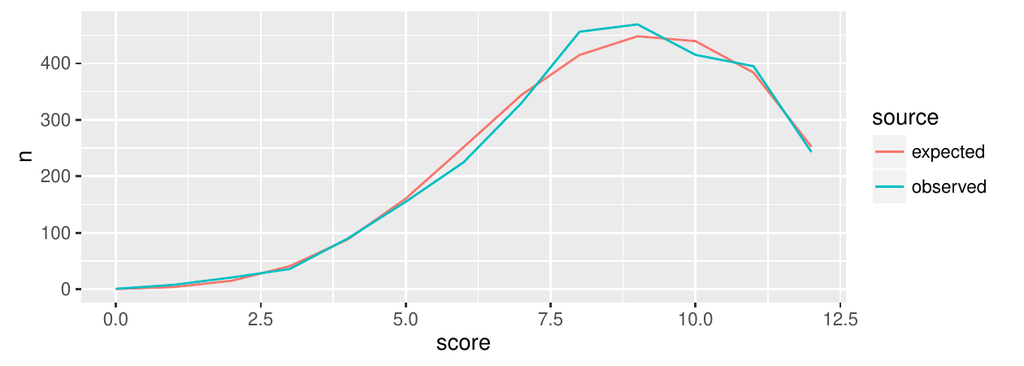

Figure 12: Comparison of the predicted and observed sum-scores.

````r
```{r,fig.height=2}
got <- sumScoreEAPTest(m1Grp)
df <- data.frame(score = as.numeric(names(got[['observed']])),
  expected = got[['expected']], observed = got[['observed']])
df <- melt(df, id = 'score', variable.name = 'source',
  value.name = 'n')
ggplot(df, aes(x = score, y = n, color = source)) + geom_line()
```
````

The first plot provides an overview of how all the items work together to predict sum-scores (Figure 12). `sumScoreEAPTest` also conducts a statistical test to produce a $p$-value, but this is not reported here because the test is fairly new and the meaning of the test has not yet been well established (Li and Cai 2012). However, it is still worth looking at this plot because you might notice something that is obviously wrong with the model (i.e., if the curves mismatch drastically).

````r
```{r,results='asis'}
ct <- ChenThissen1997(m1Grp)
print(xtable(ct$pval,
  paste('Log p-value of local dependence between item pairs.')))
```
````

Table 1: Log $p$-value of local dependence between item pairs.

|  | V1 | V2 | V3 | V4 | V5 | V6 | V7 | V8 | V9 | V10 | V11 |
| --- | --- | --- | --- | --- | --- | --- | --- | --- | --- | --- | --- |
| V2 | 0.1 |  |  |  |  |  |  |  |  |  |  |
| V3 | $-$0.0 | $-$2.6 |  |  |  |  |  |  |  |  |  |
| V4 | 1.7 | $-$0.1 | 1.2 |  |  |  |  |  |  |  |  |
| V5 | $-$0.6 | $-$0.9 | $-$1.3 | 5.1 |  |  |  |  |  |  |  |
| V6 | 0.2 | 0.1 | $-$0.3 | 0.3 | $-$1.1 |  |  |  |  |  |  |
| V7 | 0.1 | 6.4 | 0.6 | 2.4 | 0.3 | 5.0 |  |  |  |  |  |
| V8 | $-$0.5 | $-$0.3 | $-$0.7 | $-$4.0 | $-$0.2 | 0.1 | 3.9 |  |  |  |  |
| V9 | 3.6 | 10.7 | 1.1 | 2.6 | 1.8 | 5.8 | 37.1 | 0.3 |  |  |  |
| V10 | $-$2.0 | 9.1 | 0.3 | $-$0.3 | 0.1 | $-$0.2 | 10.2 | $-$0.5 | 16.2 |  |  |
| V11 | $-$1.0 | $-$11.5 | $-$2.6 | $-$1.1 | $-$0.6 | $-$1.4 | $-$1.9 | $-$4.8 | $-$0.5 | $-$0.7 |  |
| V12 | $-$0.1 | $-$1.7 | 3.9 | $-$2.9 | $-$1.9 | $-$0.7 | 0.8 | $-$2.0 | $-$0.1 | 0.6 | $-$7.1 |

A test of local dependence is important to examine, as it is an assumption of IFA (Yen 1993). Table 1 exhibits the log $p$-value of the null hypothesis that there is no local dependence between item pairs. Since $\log(.01) \approx -4.6$, any absolute magnitude greater than 4.6 can be interpreted as rejecting the null hypothesis at the .01 level. The sign of each $p$-value is determined by *ordinal gamma*, a measure of association (Agresti 1990). Positive numbers indicate more correlation than expected. These are cause for concern and suggest local dependence (Chen and Thissen 1997). Negative numbers indicate less correlation than expected. Table 1 is also a good example of a weakness of comparing expected and observed frequencies: all you can know is that *something* is suboptimal, but not specifically what. The local dependence is most severe between item pairs V7/V9, V9/V10, and V2/V9. Item pair V2/V11 also has a large magnitude value, but this is less of a concern because the sign is negative. Unfortunately, this diagnostic only reveals potential deficiencies, but does not suggest how to address them. Improvement of the model (or the items) often requires some guesswork and trial-and-error.

````r
```{r,results='asis'}
sfit <- SitemFit(m1Grp)
tbl <- t(sapply(sfit, function(r)
  c(n = r$n, df = r$df, stat = r$statistic, pval = r$pval)))
print(xtable(tbl, paste0('Sum-score item-wise fit.'))
```
````

Table 2: Sum-score item-wise fit.

|  | n | df | statistic | $\log p$-value |
| --- | --- | --- | --- | --- |
| V1 | 2844 | 8 | 6.58 | $-$0.54 |
| V2 | 2844 | 8 | 7.30 | $-$0.68 |
| V3 | 2844 | 8 | 7.17 | $-$0.66 |
| V4 | 2844 | 8 | 10.12 | $-$1.36 |
| V5 | 2844 | 8 | 19.00 | $-$4.21 |
| V6 | 2844 | 8 | 8.50 | $-$0.95 |
| V7 | 2844 | 9 | 33.45 | $-$9.10 |
| V8 | 2844 | 9 | 5.48 | $-$0.24 |
| V9 | 2844 | 9 | 34.42 | $-$9.49 |
| V10 | 2844 | 10 | 12.61 | $-$1.40 |
| V11 | 2844 | 8 | 43.06 | $-$13.97 |
| V12 | 2844 | 8 | 20.20 | $-$4.64 |

Sum-score item fit is another tool for model assessment (Orlando and Thissen 2000; Kang and Chen 2008). Each item is tested against the null hypothesis that the other items accurately predict the outcome of the item of interest (Table 2). Again $p$-values are in log units so a magnitude larger than 4.6 is significant at the .01 level. In contrast to the test for local dependence, the sign of the $p$-value does not mean anything special here. The column $n$ is included for data sets with missingness. When there is missingness, it can be advantageous to exclude the item with the most missing values to increase the sample size of the test. Refer to the `SitemFit` help for details on the options for missing data.

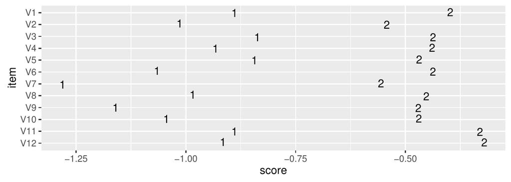

Figure 13: Item outcome by average latent score.

````r
```{r,fig.height=2}
map1 <- itemResponseMap(m1Grp, factor = 1)
ggplot(map1, aes(x = score, y = item, label = outcome)) +
  geom_text(size = 4, position = position_jitter(h = .25))
```
````

An item response map is a crude tool for diagnosing certain model misspecifications (Figure 13). Each outcome is assigned the average latent score of all the examinees who picked that outcome. Usually we advocate the use of the actual outcome labels (e.g., “incorrect” and “correct”) instead of numbers. For this plot, however, we make an exception because the numbers make it easy to inspect whether the outcomes are in ascending order. If descending order is observed then it is worth checking whether the item needs to be reverse scored or to consider whether the item was misinterpreted by some examinees. If the response data were manually collected then the data entry process should also be checked for errors.

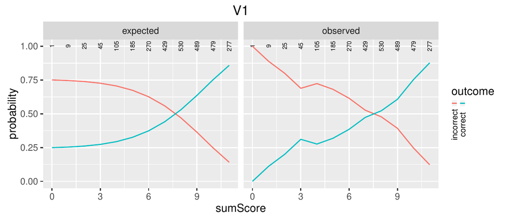

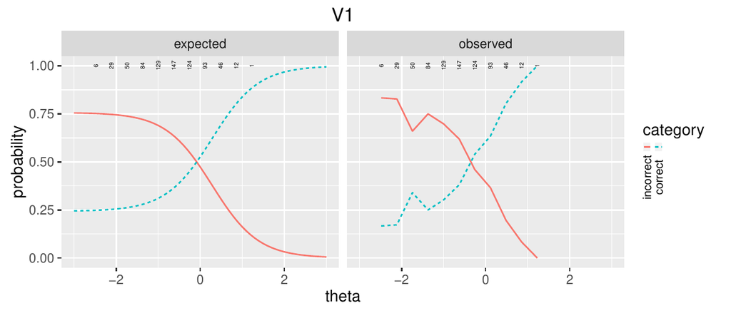

Figure 14: (left) Expected and observed outcome by sum-score. (right)Expected and observed outcome by latent score.

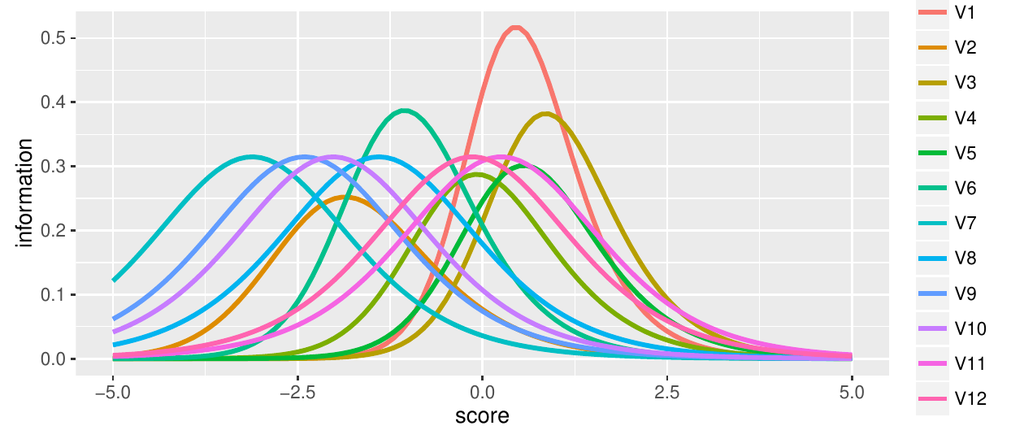

Figure 15: Item information by latent score.

````r
```{r,fig.height=3}
pl <- lapply(names(sfit), function(item) { SitemPlot(sfit, item) })
for (px in 1:length(pl)) {
  print(pl[[px]])
}
````

Two approaches are available to plot response probability functions against a latent trait. The same ingredients that go into the production of Table 2 can also be plotted (Figure 14). A similar plot can be obtained by plotting the outcomes probabilities against the latent trait. This is known as an item characteristic curve plot (Figure 14). The main advantage of `SitemPlot` over `iccPlot` is that `SitemPlot` is one-dimensional regardless of the number of latent factors. With `iccPlot`, you must pick a basis vector in the latent space. The tiny numbers across the probability = 1 line of Figures 14 and 14 are the sample size at that point on the $x$ axis.

````r
basis <- rep(0, length(factors))
basis[1] <- 1
plotInformation(m1Grp, width = 5, basis = basis)
```
````

Figure 15 exhibits item information by latent score. Similar to `iccPlot`, this plot requires the selection of a basis vector when there is more than 1 latent factor. Notice that items V7-V12 peak at the same height (near 0.31). This is due to our equality constraint on the slope or factor loading on these items. By placing this constraint, we assume a priori that each of these items contributes exactly the same amount of information.

````r
```{r}
summary(m1Fit)
```
````

```r
Summary of container

free parameters:
                   name         matrix     row col Estimate Std.Error
1   itemModel.item[1,1] itemModel.item ability  V1     1.82     0.278
2   itemModel.item[2,1] itemModel.item      p2  V1    -0.51     0.230
3                  V1_g itemModel.item      p3  V1    -1.14     0.208
4   itemModel.item[1,2] itemModel.item ability  V2     1.24     0.119
5   itemModel.item[2,2] itemModel.item      p2  V2     2.58     0.140
6                  V2_g itemModel.item      p3  V2    -1.27     0.337
7   itemModel.item[1,3] itemModel.item ability  V3     1.56     0.261
8   itemModel.item[2,3] itemModel.item      p2  V3    -1.03     0.272
9                  V3_g itemModel.item      p3  V3    -1.16     0.192
10  itemModel.item[1,4] itemModel.item ability  V4     1.36     0.161
11  itemModel.item[2,4] itemModel.item      p2  V4     0.41     0.158
12                 V4_g itemModel.item      p3  V4    -1.10     0.277
13  itemModel.item[1,5] itemModel.item ability  V5     1.41     0.196
14  itemModel.item[2,5] itemModel.item      p2  V5    -0.47     0.203
15                 V5_g itemModel.item      p3  V5    -1.03     0.203
16  itemModel.item[1,6] itemModel.item ability  V6     1.50     0.130
17  itemModel.item[2,6] itemModel.item      p2  V6     1.84     0.119
18                 V6_g itemModel.item      p3  V6    -1.43     0.317
19                slope itemModel.item ability  V7     1.12     0.037
20  itemModel.item[2,7] itemModel.item      p2  V7     3.50     0.097
21  itemModel.item[2,8] itemModel.item      p2  V8     1.57     0.056
22  itemModel.item[2,9] itemModel.item      p2  V9     2.70     0.075
23 itemModel.item[2,10] itemModel.item      p2 V10     2.27     0.066
24 itemModel.item[2,11] itemModel.item      p2 V11    -0.28     0.047
25 itemModel.item[2,12] itemModel.item      p2 V12     0.15     0.047

observed statistics:  720
estimated parameters:  25
degrees of freedom:  695
fit value ( -2lnL units ):  33453
number of observations:  2844
Information Criteria:
      |  df Penalty  |  Parameters Penalty  |  Sample-Size Adjusted
AIC:          32063                  33503                       NA
BIC:          27926                  33652                    33573
To get additional fit indices, see help(mxRefModels)
timestamp: 2016-02-24 10:14:59
Wall clock time (HH:MM:SS.hh): 00:00:02.72
OpenMx version number: 2.3.1.254
Need help?  See help(mxSummary)
```

Exhibited above is the *OpenMx* provided summary of model fit. IFA models are exponential family models so we obtain AIC and BIC. More fit statistics are available if we provide the saturated and independence reference models. Reference models will be requested in our next example.

# Polytomous data

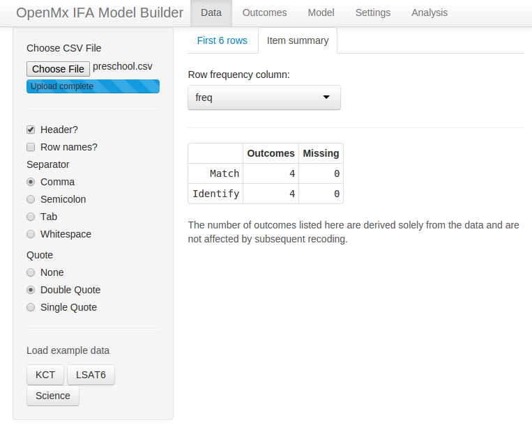

Figure 16: Data with a row frequency column.

Since many things are common between dichotomous and polytomous items, we will move quickly through the process of model set up and result interpretation. Click on the “`Choose File`” button and select `preschool.csv`, a data set from David Thissen and Steinberg (1988) available in the *ifaTools* package. Click the “`Row names?`” checkbox in the control panel to disable row names. The format of these data are closer to what is expected by default than our first example so less fiddling is required. Click on the “`Item summary`” tab. Here it appears that there are 3 items, but the `freq` column is not an item. `freq` indicates how many times a row appeared in the original data. These data are compressed; only unique rows are provided with frequency counts. To instruct the model builder to interpret the `freq` column as frequency counts, select `freq` from the “`Row frequency column`” selector (Figure 16).

This data set is from a preschool test of numerical knowledge. Each item is actually a combination of 2 dichotomous items. Similar questions were asked regarding the number 3 and the number 4 and the pattern of responses mapped to an outcome code. The outcomes should be renamed with the recoding tool under the “`Outcomes`” tab on the top bar (recall Figure 7). Outcomes 0, 1, 2, and 3 should be renamed to “neither,” “3 only,” “4 only,” and “both correct,” respectively, using the “`Recode`” tab under the `Outcomes` top bar page. After renaming, reorder the items into the correct order (Figure 17).

Click `Model` on the top bar. On the “`Factors`” tab, we will name the single latent factor “math.” Switch to the `Parameters` tab. Here we select `nrm` from the “`Model`” selector. The acronym “nrm” stands for the nominal response model (D. Thissen, Cai, and Bock 2010). This parameterization of the nominal model can accommodate basis matrices $T_a$ and $T_c$ to customize the meaning of the slope and intercept coefficients, respectively. In principle, the basis matrices can take any pattern, but the model builder app is limited to a Fourier basis (a.k.a. trend basis) for the $T_a$ matrix and a small number of options for the $T_c$ matrix.

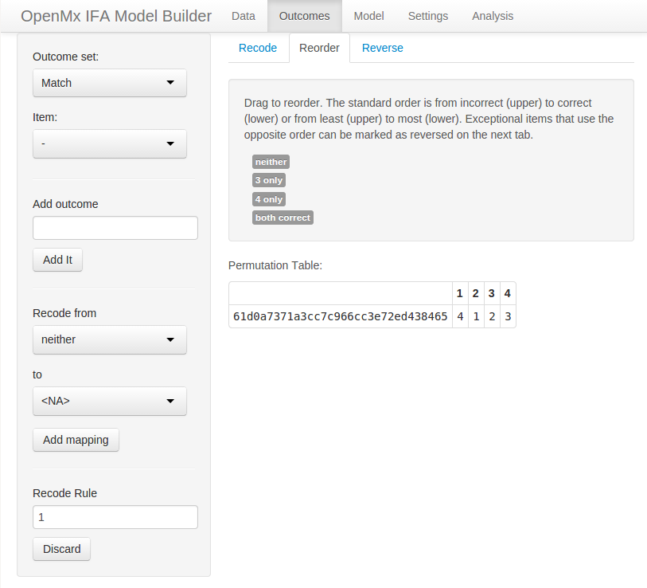

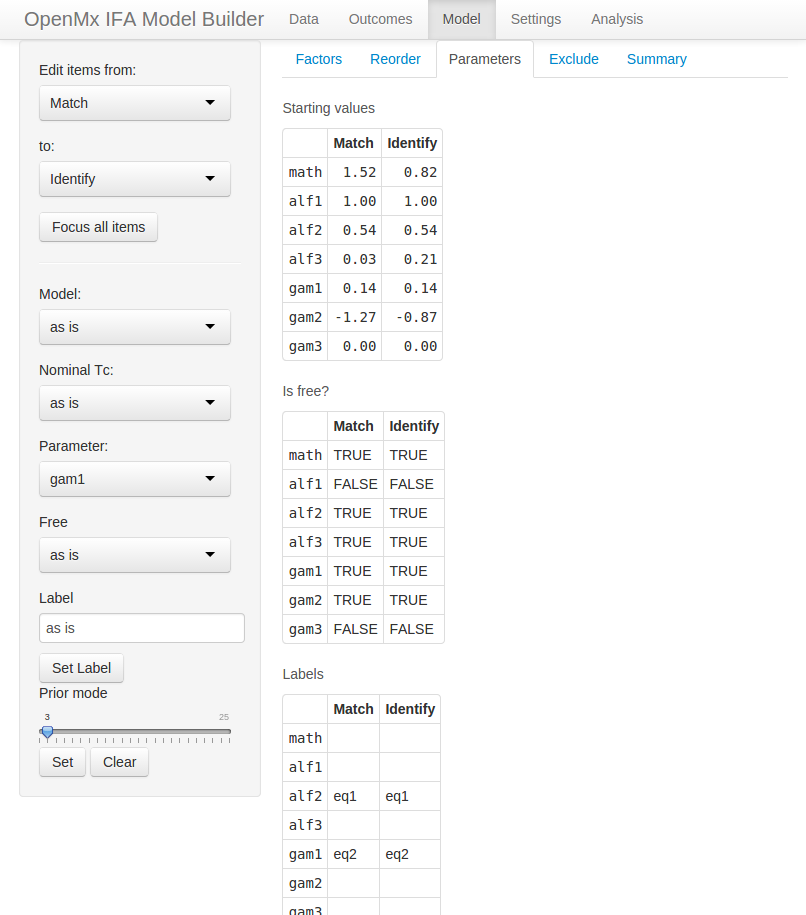

Figure 17: (left)Outcomes renamed and reordered. (right) Item model and parameter configuration with equality constraints.

With $T_a$ set to the trend basis, we cannot free both `math` and `alf1` because they have the same effect on the model and would cause the model to be unidentified. Fix `alf1` to 1. Select `alf1` from the “`Parameter`” selector and select 1 from the “`Free`” selector. Since we have worked with this data set already, we know a few things that can give us a more parsimonious model. The `alf2` parameters can be set equal since both items exhibit poor discrimination between `neither`, `3 only`, and `4 only` but good discrimination between these outcomes and `both correct`. Select `alf2` with the “`Parameter`” selector and set the label to `eq1`. Since both items are equally difficult, we can equate `gam1`. Select `gam1` with the “`Parameter`” selector and set the label to `eq2`. To avoid overfitting with the highest frequency basis vector, fix `gam3` to 0. Select `gam3` with the `Parameter` selector and select `0` with the `Free` selector. Figure 17 exhibits the final parameter settings.

Click `Analysis` on the top bar. Ensure that “`Fit reference models`” is selected, and download the analysis script. The `Rmarkdown` file and your data need to be in the same directory. Either move the `Rmarkdown` file to your data directory, or alternately, you can specify a full path in the read.csv statement (line 162). Open the file in *RStudio* and click the “`Knit HTML`” button. Although this is a simple model, it can take almost 100 E-M cycles to converge. Therefore, we omit reproduction of the diagnostic output issued during model fit.

````r
---
title: "preschool"
date: "18-Nov-2014"
output: html_document
---

```{r}
options(width = 120, scipen = 2, digits = 2)
suppressPackageStartupMessages(library(OpenMx))
suppressPackageStartupMessages(library(rpf))
suppressPackageStartupMessages(library(ifaTools))
library(xtable)
options(xtable.type = 'html')

# Adjust the path in the next statement to load your data
data <- read.csv(file = 'preschool.csv', stringsAsFactors = FALSE,
  check.names = FALSE) ## \label{e3:load}
colnames(data) <- mxMakeNames(colnames(data), unique = TRUE)
data[['freq']] <- as.numeric(data[['freq']]) ## \label{e3:freq}

factors <- "math"
numFactors <- length(factors)
spec <- list()
spec[1:2] <- rpf.nrm(factors = numFactors, outcomes = 4,
  T.a = 'trend', T.c = 'trend') ## \label{e3:nominal}
names(spec) <- c("Match", "Identify")

missingColumns <- which(is.na(match(names(spec), colnames(data))))
if (length(missingColumns)) {
  stop(paste('Columns missing in the data:',
       omxQuotes(names(spec)[missingColumns])))
}

data[names(spec)] <- mxFactor(data[names(spec)], levels = 0:3,
  labels = c("neither", "3 only", "4 only", "both correct"))

set.seed(1)   # uncomment to get the same starting values every time
startingValues <- mxSimplify2Array(lapply(spec, rpf.rparam))
rownames(startingValues) <- paste0('p', 1:nrow(startingValues))
rownames(startingValues)[1:numFactors] <- factors

imat <- mxMatrix(name = 'item', values = startingValues,
  free = !is.na(startingValues))
imat$free['p2',] <- FALSE
imat$values['p2',1:2] <- 1
imat$free['p7',] <- FALSE
imat$values['p7',1:2] <- 0
imat$labels['p3',] <- 'eq1'
imat$labels['p5',] <- 'eq2'
hasLabel <- !is.na(imat$labels)
for (lab1 in unique(imat$labels[hasLabel])) {
  imat$values[hasLabel & imat$labels == lab1] <-    ## \label{e3:equality}
    sample(imat$values[hasLabel & imat$labels == lab1], 1)
}
itemModel <- mxModel(model = 'itemModel', imat,
  mxData(observed = data, type = 'raw', numObs = sum(data[['freq']]),
    sort = FALSE), ## \label{e3:sort}
  mxExpectationBA81(ItemSpec = spec, weightColumn = 'freq'),
  mxFitFunctionML())

emStep <- mxComputeEM('itemModel.expectation', 'scores',
  mxComputeNewtonRaphson(), verbose = 2L,
  information = 'oakes1999',
  infoArgs = list(fitfunction = 'fitfunction'))
computePlan <- mxComputeSequence(list(emStep,
         mxComputeHessianQuality(),
         mxComputeStandardError()))

m1Fit <- mxRun(mxModel(itemModel, computePlan))

m1Grp <- as.IFAgroup(m1Fit, minItemsPerScore = 1L)
```
````

Although response pattern frequencies are typically natural numbers, fractional frequencies are not prohibited (line 164). A Fourier basis is used for both nominal model transformation matrices (line 170). Customization is limited in the model builder app, but you can use any matrices by editing the generated code. Starting values must respect equality constraints (line 197). By default *OpenMx*, sorts data prior to optimization. Since our data are already compressed, no benefit would be obtained by sorting (line 202).

```r
An item factor model was fit with ` length(factors)`
factors (` factors`), -2LL = $` m1Fit$output$fit`$.
The condition number of the information matrix was
` round(m1Fit$output$conditionNumber)`.
```

The boilerplate renders as, “An item factor model was fit with 1 factors (math), $-2$LL = $2767.48$. The condition number of the information matrix was 85.07.” Since we have already seen much of the code to generate model diagnostics, we omit it here.

Table 3: Sum-score item-wise fit.

|  | n | df | statistic | $\log p$-value |
| --- | --- | --- | --- | --- |
| Match | 592 | 7 | 9.46 | $-$1.51 |
| Identify | 592 | 7 | 9.33 | $-$1.47 |

````r
```{r}
summary(m1Fit, refModels = mxRefModels(m1Fit, run = TRUE))  ## \label{e3:refModels}
```
````

```r
Summary of itemModel

free parameters:
                 name matrix  row      col Estimate Std.Error
1 itemModel.item[1,1]   item math    Match     0.82      0.37
2                 eq1   item   p3    Match    -1.18      0.27
3 itemModel.item[4,1]   item   p4    Match     0.50      0.19
4                 eq2   item   p5    Match     0.18      0.05
5 itemModel.item[6,1]   item   p6    Match    -0.78      0.20
6 itemModel.item[1,2]   item math Identify     0.79      0.35
7 itemModel.item[4,2]   item   p4 Identify    -0.25      0.36
8 itemModel.item[6,2]   item   p6 Identify    -1.40      0.21

observed statistics:  15
estimated parameters:  8
degrees of freedom:  7
fit value ( -2lnL units ):  2767
saturated fit value ( -2lnL units ):  2758
number of observations:  592
chi-square:  X2 ( df=7 ) = 9.2,  p = 0.24
Information Criteria:
      |  df Penalty  |  Parameters Penalty  |  Sample-Size Adjusted
AIC:           2753                   2783                       NA
BIC:           2723                   2819                     2793
CFI: 0.98
TLI: 0.97   (also known as NNFI)
RMSEA:  0.023  [95% CI (0, 0.064)]
Prob(RMSEA <= 0.05): 0.88
timestamp: 2016-02-24 10:15:07
Wall clock time (HH:MM:SS.hh): 00:00:04.55
OpenMx version number: 2.3.1.254
Need help?  See help(mxSummary)
```

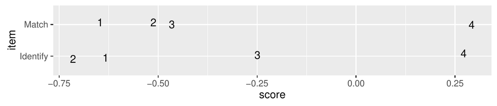

Figure 18: Item outcome by average latent score.

Although the outcomes are not strictly ordered for `Identify` in the item outcome map (Figure 18), other measures of model fit look reasonable. The sum-score item fit tests are not statistically significant at the 0.01 level (Table 3). This indicates good item-level fit. Since we requested a saturated and independence model (`mxRefModels`; line 223), CFI (Comparative Fit Index), TLI (Tucker Lewis Index), and RMSEA (Root Mean Square Error of Approximation) are available in the *OpenMx* summary and suggest adequate model fit. These relative indices of fit are appropriate for these data because there are observations for all possible response patterns. However, be forewarned that as the multinomial table becomes more sparse, these indices become inaccurate. For sparse data, a more accurate assessment of model fit is available using other methods (Bartholomew and Tzamourani 1999; Cai and Hansen 2013).

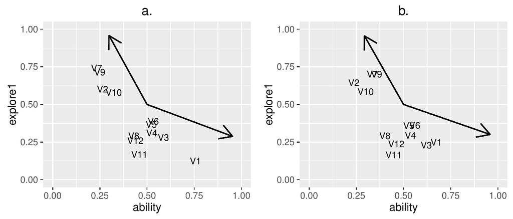

Figure 19: Factor loadings for items with (a) and without (b) the slope constraint. The code for `plotTwoFactors` is given in the Appendix.

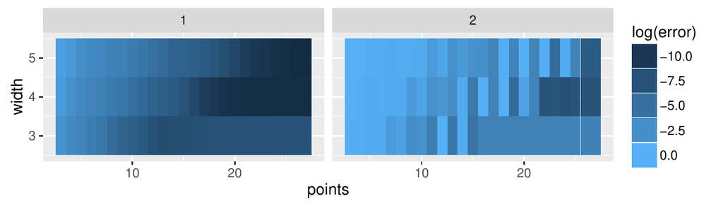

Figure 20: Log Euclidean distance ($l^2$-norm) of error by quadrature width and number of points for 1 factor (left) and 2 factors (right). A wider width is important to accommodate data that conform less closely to a normal distribution. Even with clean simulated data, a width of 3 is too narrow and interferes with accuracy (both panes). In the 1 factor case (left), at least 21 points are required for high accuracy. For 2 factors (right), at least 23 points are required for a width of 4 and 27 points for a width of 5. The bright strips at even numbers of point (12, 14, 16, etc) indicate that an odd number of points obtain somewhat better accuracy than even numbers of points.

```r
> container2 <- container
> container2$itemModel$item$labels['ability', ] <- NA
> m3 <- addExploratoryFactors(container2, 0)
> m3 <- mxRun(m3, silent = TRUE)
> mxCompare(m3, m1)
        base comparison ep minus2LL  df   AIC diffLL diffdf       p
1 container1       <NA> 30    33369 690 31989     NA     NA      NA
2 container1 container1 25    33454 695 32064     85      5 7.7e-17
> m4 <- addExploratoryFactors(container2, 1)
> m4 <- mxRun(m4, silent = TRUE)
> mxCompare(m4, m2)
        base comparison ep minus2LL  df   AIC diffLL diffdf     p
1 container2       <NA> 41    33325 679 31967     NA     NA    NA
2 container2 container2 36    33339 684 31971     14      5 0.013
> grid.arrange(plotTwoFactors(m2$itemModel$item$values[1:2, ]) +
+   labs(title = "a."), plotTwoFactors(m4$itemModel$item$values[1:2, ]) +
+   labs(title = "b."), ncol = 2)
```

# Rasch diagnostics

A Rasch model is obtained when all slope parameters are constrained to be equal and the variance is fixed to 1.0, or equivalently, all slopes are fixed to 1.0 with free variance (Rasch 1960/1993). If your interest is Rasch models with a single latent factor then you can take advantage of Rasch residual-based fit statistics. Infit and outfit are available from `pf.1dim.fit`.

# Item factor analysis

A common problem is that we do not know how many latent factors to employ to most accurately model our data. Fortunately, there is a method item factor analysis (Bock, Gibbons, and Muraki 1988) analogous to factor analysis of continuous indicators (Lovie and Lovie 1996). We will employ the likelihood ratio test for inference. The likelihood ratio test is asymptotically consistent for sparse multinomial distributions (Haberman 1977). However, in finite samples, we should not expect that the null distribution is well calibrated. In brief, the $p$-values should not be taken too seriously.

```r
> m1 <- addExploratoryFactors(container, 0)
> m1 <- mxRun(m1, silent = TRUE)
> m2 <- addExploratoryFactors(container, 1)
> m2 <- mxRun(m2, silent = TRUE)
> mxCompare(m2, m1)
        base comparison ep minus2LL  df   AIC diffLL diffdf       p
1 container2       <NA> 36    33339 684 31971     NA     NA      NA
2 container2 container1 25    33454 695 32064    115     11 1.5e-19
```

Here we find that there is reasonably good support in favor of a two factor solution. However, the slope of items 7-12 are constrained equal. Maybe this constraint was a mistake. It is possible that these items are well modeled by a single factor when all the slopes are freed. We cannot directly compare `m2` against a single factor model without the slope constraint because these models are not nested. However, we can make a number of similar comparisons.

We find that there is a dramatic improvement in fit whether we relax the constraint on items 7-12 or we add another factor. Without knowing more about how the data were collected, parsimony favors a single factor model without constraints on the slopes. We can further check this idea by comparison of two factor models with and without the slope constraint (Figure 19).

A $p$-value of 0.013 is statistically significant at the customary 0.05 level, but we regard this as non-significant in comparison to the other $p$-values that are less than $10^{-16}$. We conclude that there is no difference between these models. For two factor models, it can be helpful to plot item factor loadings. A varimax rotation eliminates rotational indeterminacy. Promax axes are helpful to illustrate the rough directions of variability (Bock, Gibbons, and Muraki 1988, 265). In both plots, the promax axes are separated by an angle close to $\pi$ radians, suggesting a single latent factor. The slight differences between plots (a) and (b) are probably due to overfitting. More precise $p$-values could be obtained using Monte Carlo techniques.

# Repercussions of the use of numerical quadrature for integration

Recall that the optimization algorithm uses equal interval quadrature to evaluate the integral in Equation @ref(eq:integral). It is important to understand how the quadrature grid influences model optimization accuracy and time. Let $Q$ be the number of quadrature points per dimension and $Q_{width}$ be the one-sided width of the quadrature for one dimension. Points $X_q$ are arranged as
$$\begin{aligned}
\label{eq:quadrature}
X_q &= Q_{width} (1 - \frac{2q}{Q-1}) \quad\text{for } q \in \{0,
\dots, Q-1\}.
\end{aligned} (\#eq:quadrature)$$
Generalization to more dimensions is accomplished by replication of the same 1 dimensional grid along each dimension. For example, a two factor model with 31 points per dimension involve $31^2 = 961$ grid points. Hence, optimization time is exponential in the number of general factors.

Figure 20 exhibits a simulation study of the influence of quadrature on model accuracy. All comparisons are against a 41 point quadrature of width 5.0. Before computing the Euclidean distance ($l^2$-norm), the slope matrix was converted into factor loadings,
$$\frac{\mathrm{slope}}{\left[ 1 +
\mathrm{rowSums}(\mathrm{slope}^2) \right]^\frac{1}{2}}.$$
For two factor models, a varimax rotation was applied to eliminate rotational indeterminacy. The $l^2$-norm was applied to the resulting slope entries (ignoring intercepts). Each grid area in Figure 20 represents the average of 5 trials with different random starting values.

Item factor analysis with more than two factors requires patience and expertise. Model optimization time becomes an uncomfortable hindrance to experimentation. An optimization algorithm better suited to many latent factors, such as the Metropolis-Hastings Robbins-Monro algorithm (Cai 2010b), is not yet available in *OpenMx*. The model builder offers as many as five factors because additional factors do not always increase estimation time. Suppose all items load on a general factor. In the special case that each item loads on at most one additional factor, many additional factors will not increase estimation time. One important use for this kind of factor structure is to account for local dependence (DeMars 2006). For example, a reading comprehension test might have 3-4 items that relate to a single passage. The items within each passage will likely exhibit local dependence. One way to account for this kind of test structure is to add passage specific latent factors. Since the passages are disjoint, all of the passage specific factors will count as a single factor with respect to estimation time (Cai 2010a).

# Discussion

We gave detailed instructions on how to set up IFA models for analysis of both dichotomous and polytomous data using the model builder app. We hope this will ease the learning curve for the construction of IFA models in *OpenMx*. The model builder app offers limited flexibility by design to reduce the number of options for novice users. For example, there is no facility for construction of multiple group models. This may be construed as a disadvantage, but we argue that keeping the app as simple as possible is important for newcomers to IFA. Learning *OpenMx* can be a daunting prospect. *OpenMx*, *rpf*, and *ifaTools* are free software. The source code is available for everybody to view, modify, and use. If you find this software useful, we hope you will cite us in your publications.

# Appendix

Factors are plotted in a coordinate system determined by a varimax rotation (line 2). Promax axes are superimposed (line 9).

```r
plotTwoFactors <- function(slope) {
  lvm <- varimax(toFactorLoading(slope))$loadings   ## \label{e4:varimax}
  if (any(abs(lvm[lvm < 0]) > .001)) stop("Got negative loadings")
  lvm[lvm<0] <- 0
  df <- as.data.frame(lvm[, 1:2])
  df$name <- rownames(df)
  pl <- ggplot(df, aes_string(x = rownames(slope)[1],
    y = rownames(slope)[2], label = "name")) + geom_text(size = 3)
  pm <- promax(lvm[, 1:2])$rotmat   ## \label{e4:promax}
  for (dx in 1:ncol(pm)) {
    d1 <- .5 * pm[, dx] / sqrt(sum(pm[, dx]^2))
    pl <- pl + geom_segment(x = .5, y = .5, xend = d1[1] + .5,
      yend = d1[2] + .5, arrow = arrow(length = unit(.5, "cm")))
  }
  pl + xlim(0, 1) + ylim(0, 1)
}
```

Agresti, Alan. 1990. *Analysis of Categorical Data*. New York: Wiley.

Allaire, JJ, Jonathan McPherson, Yihui Xie, Hadley Wickham, Joe Cheng, and Jeff Allen. 2014. *Rmarkdown: Dynamic Documents for r*. http://rmarkdown.rstudio.com.

Baker, F. B., and S. H. Kim. 2004. *Item Response Theory: Parameter Estimation Techniques*. 2nd ed. CRC Press.

Bartholomew, David J, and Panagiota Tzamourani. 1999. “The Goodness of Fit of Latent Trait Models in Attitude Measurement.” *Sociological Methods & Research* 27 (4): 525–46.

Birnbaum, A. 1968. “Some Latent Trait Models and Their Use in Inferring an Examinee’s Ability.” In *Statistical Theories of Mental Test Scores*, edited by F. M. Lord and M. R. Novick, 397–479. Reading, MA: Addison-Wesley.

Bock, R. D., and M. Aitkin. 1981. “Marginal Maximum Likelihood Estimation of Item Parameters: Application of an EM Algorithm.” *Psychometrika* 46: 443–59.

Bock, R. D., Robert Gibbons, and Eiji Muraki. 1988. “Full-Information Item Factor Analysis.” *Applied Psychological Measurement* 12 (3): 261–80.

Cai, L. 2010a. “A Two-Tier Full-Information Item Factor Analysis Model with Applications.” *Psychometrika* 75 (4): 581–612.

———. 2010b. “High-Dimensional Exploratory Item Factor Analysis by a Metropolis-Hastings Robbins-Monro Algorithm.” *Psychometrika* 75 (1): 33–57.

Cai, L., and Mark Hansen. 2013. “Limited-Information Goodness-of-Fit Testing of Hierarchical Item Factor Models.” *British Journal of Mathematical and Statistical Psychology* 66 (2): 245–76.

Cai, L., J. S. Yang, and M. Hansen. 2011. “Generalized Full-Information Item Bifactor Analysis.” *Psychological Methods* 16 (3): 221–48.

Chen, Wen-Hung, and D. Thissen. 1997. “Local Dependence Indexes for Item Pairs Using Item Response Theory.” *Journal of Educational and Behavioral Statistics* 22 (3): 265–89.

DeMars, Christine E. 2006. “Application of the Bi-Factor Multidimensional Item Response Theory Model to Testlet-Based Tests.” *Journal of Educational Measurement* 43 (2): 145–68.

Gelman, Andrew. 2008. “Objections to Bayesian Statistics.” *Bayesian Analysis* 3 (3): 445–49.

Haberman, Shelby J. 1977. “Log-Linear Models and Frequency Tables with Small Expected Cell Counts.” *The Annals of Statistics* 5 (6): 1148–69. https://doi.org/10.1214/aos/1176344001.

Kang, Taehoon, and Troy T Chen. 2008. “Performance of the Generalized S-$X^2$ Item Fit Index for Polytomous IRT Models.” *Journal of Educational Measurement* 45 (4): 391–406.

Knuth, Donald Ervin. 1984. “Literate Programming.” *The Computer Journal* 27 (2): 97–111.

Li, Z, and Li Cai. 2012. “Summed Score Likelihood Based Indices for Testing Latent Variable Distribution Fit in Item Response Theory.” In *Annual International Meeting of the Psychometric Society*. Lincoln, NE: Retrieved from http://www.cse.ucla.edu/downloads/files/SD2-final-4.pdf.

Loken, Eric, and Kelly L Rulison. 2010. “Estimation of a Four-Parameter Item Response Theory Model.” *British Journal of Mathematical and Statistical Psychology* 63 (3): 509–25.

Lovie, P., and A. D. Lovie. 1996. “Charles Edward Spearman, F.R.S. (1863–1945).” *Notes and Records of the Royal Society* 50 (1): 75–88. https://doi.org/10.1098/rsnr.1996.0007.

Magis, David. 2013. “A Note on the Item Information Function of the Four-Parameter Logistic Model.” *Applied Psychological Measurement* 37 (4): 304–15.

Neale, M. C., M. D. Hunter, J. N. Pritikin, M. Zahery, Timothy R Brick, R. Kirkpatrick, R. Estabrook, T. C. Bates, H. Maes, and S. M. Boker. in press.“ 2.0: Extended Structural Equation and Statistical Modeling.” *Psychometrika*, in press. https://doi.org/10.1007/s11336-014-9435-8.

Nosek, BA, G Alter, GC Banks, D Borsboom, SD Bowman, SJ Breckler, S Buck, et al. 2015. “Promoting an Open Research Culture.” *Science* 348 (6242): 1422–25.

Oakes, David. 1999. “Direct Calculation of the Information Matrix via the EM Algorithm.” *Journal of the Royal Statistical Society B (Statistical Methodology)* 61 (2): 479–82.

Orlando, M., and D. Thissen. 2000. “Likelihood-Based Item-Fit Indices for Dichotomous Item Response Theory Models.” *Applied Psychological Measurement* 24 (1): 50–64.

Peng, Roger D. 2011. “Reproducible Research in Computational Science.” *Science* 334 (6060): 1226.

Pritikin, J. N. 2015a. *ifaTools: Toolkit for Item Factor Analysis with OpenMx. Computer Software* (version 0.8). https://CRAN.R-project.org/package=ifaTools.

———. 2015b. *Rpf: Response Probability Functions. Computer Software* (version 0.51). https://CRAN.R-project.org/package=rpf.

Pritikin, J. N., M. D. Hunter, and S. M. Boker. 2015. “Modular Open-Source Software for Item Factor Analysis.” *Educational and Psychological Measurement* 75 (3): 458–74. https://doi.org/10.1177/0013164414554615.

Rasch, Georg. 1960/1993. *Probabilistic Models for Some Intelligence and Attainment Tests*. MESA Press.

RStudio, and Inc. 2014. *Shiny: Web Application Framework for r*. http://CRAN.R-project.org/package=shiny.

Samejima, Fumiko. 1969. “Estimation of Latent Ability Using a Response Pattern of Graded Scores.” *Psychometrika Monograph Supplement* 34 (4): 100.

Thissen, David, and Lynne Steinberg. 1988. “Data Analysis Using Item Response Theory.” *Psychological Bulletin* 104 (3): 385–95.

Thissen, D., L. Cai, and R. D. Bock. 2010. “The Nominal Categories Item Response Model.” In *Handbook of Polytomous Item Response Theory Models*, edited by Michael L. Nering and Remo Ostini, 43–75. Routledge.

Thissen, D., Lynne Steinberg, and Jo Ann Mooney. 1989. “Trace Lines for Testlets: A Use of Multiple-Categorical-Response Models.” *Journal of Educational Measurement* 26 (3): 247–60.

Yen, Wendy M. 1993. “Scaling Performance Assessments: Strategies for Managing Local Item Dependence.” *Journal of Educational Measurement* 30 (3): 187–213.

[^1]: It may read “`Choose CSV File`’.” The exact appearance may differ on your system.
[^2]: We are aware that these screenshots are illegible when printed on paper. Inspect them using magnification on your computer.